# Regresja liniowa i wieloraka - projekt

Kwiek Kamil

Zaimportujemy zbiór danych `Carseats` z biblioteki `ISLR` i dopasujemy model (lub modele) regresji liniowej prostej przewidujący wartość zmiennej *Sales*. Zmienną objaśniającą dobierzemy według znanych metod (współczynnik korelacji, wykresy). Ocenimy jakość modelu ($R^2$, błąd standardowy) i zweryfikujemy założenia (analiza reszt).

# Regresja liniowa

### Przedstawienie oraz opis danych

```r
carseats <- tibble::as.tibble(ISLR::Carseats)
head(carseats)
```

| Sales | CompPrice | Income | Advertising | Population | Price | ShelveLoc | Age | Education | Urban | US |
| --- | --- | --- | --- | --- | --- | --- | --- | --- | --- | --- |
| 9.50 | 138 | 73 | 11 | 276 | 120 | Bad | 42 | 17 | Yes | Yes |
| 11.22 | 111 | 48 | 16 | 260 | 83 | Good | 65 | 10 | Yes | Yes |
| 10.06 | 113 | 35 | 10 | 269 | 80 | Medium | 59 | 12 | Yes | Yes |
| 7.40 | 117 | 100 | 4 | 466 | 97 | Medium | 55 | 14 | Yes | Yes |
| 4.15 | 141 | 64 | 3 | 340 | 128 | Bad | 38 | 13 | Yes | No |
| 10.81 | 124 | 113 | 13 | 501 | 72 | Bad | 78 | 16 | No | Yes |

Zbiór `Carseats` przedstawia sprzedaż fotelików samochodowych dla dzieci w 400 różnych sklepach. Zawiera 11 zmiennych:

- `Sales` – sprzedaż jednostkowa (w tysiącach) w każdej lokalizacji,
- `CompPrice` – cena pobierana przez konkurenta w każdej lokalizacji,
- `Income` – poziom dochodów społeczności (w tysiącach dolarów),
- `Advertising` – budżet na reklamę lokalną dla firmy w każdej lokalizacji (w tys. dolarów),
- `Population` – wielkość populacji w regionie (w tysiącach),
- `Price` – cena jaką firma pobiera za foteliki samochodowe w każdym miejscu,
- `ShelveLoc` – czynnik o poziomach *Bad*, *Good* i *Medium* wskazujący na jakość lokalizacji półek na foteliki samochodowe w każdej placówce,
- `Age` – średni wiek lokalnej populacji,
- `Education` – poziom wykształcenia w każdej lokalizacji,
- `Urban` – czynnik o poziomach *No* i *Yes* wskazujący, czy sklep znajduje się w lokalizacji miejskiej (dla *No* miejscem zamieszkania jest wieś),
- `US` – czynnik o poziomach *No* i *Yes* wskazujący, czy sklep znajduje się w USA czy nie.

```r
kable(summary(carseats), escape = F) %>%
  kable_styling(latex_options = "hold_position")
```

|  | Sales | CompPrice | Income | Advertising | Population | Price | ShelveLoc | Age | Education | Urban | US |
| --- | --- | --- | --- | --- | --- | --- | --- | --- | --- | --- | --- |
|  | Min. : 0.000 | Min. : 77 | Min. : 21.00 | Min. : 0.000 | Min. : 10.0 | Min. : 24.0 | Bad : 96 | Min. :25.00 | Min. :10.0 | No :118 | No :142 |
|  | 1st Qu.: 5.390 | 1st Qu.:115 | 1st Qu.: 42.75 | 1st Qu.: 0.000 | 1st Qu.:139.0 | 1st Qu.:100.0 | Good : 85 | 1st Qu.:39.75 | 1st Qu.:12.0 | Yes:282 | Yes:258 |
|  | Median : 7.490 | Median :125 | Median : 69.00 | Median : 5.000 | Median :272.0 | Median :117.0 | Medium:219 | Median :54.50 | Median :14.0 | NA | NA |
|  | Mean : 7.496 | Mean :125 | Mean : 68.66 | Mean : 6.635 | Mean :264.8 | Mean :115.8 | NA | Mean :53.32 | Mean :13.9 | NA | NA |
|  | 3rd Qu.: 9.320 | 3rd Qu.:135 | 3rd Qu.: 91.00 | 3rd Qu.:12.000 | 3rd Qu.:398.5 | 3rd Qu.:131.0 | NA | 3rd Qu.:66.00 | 3rd Qu.:16.0 | NA | NA |
|  | Max. :16.270 | Max. :175 | Max. :120.00 | Max. :29.000 | Max. :509.0 | Max. :191.0 | NA | Max. :80.00 | Max. :18.0 | NA | NA |

### Założenie 1: Zależność liniowa

Przekształcamy *“tibbl’a”* ze wszystkimi zmiennymi na mniejszą wersję, zawierającą wyłącznie zmienne ciągłe.

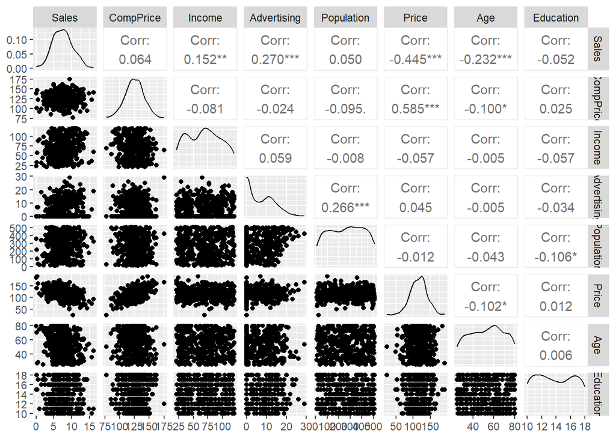

```r
subcarseats <- subset(carseats, select=-ShelveLoc)
ggpairs(subcarseats[1:8])
```

Sprawdzimy teraz rozkład tych dwóch zmiennych za pomocą histogramów.

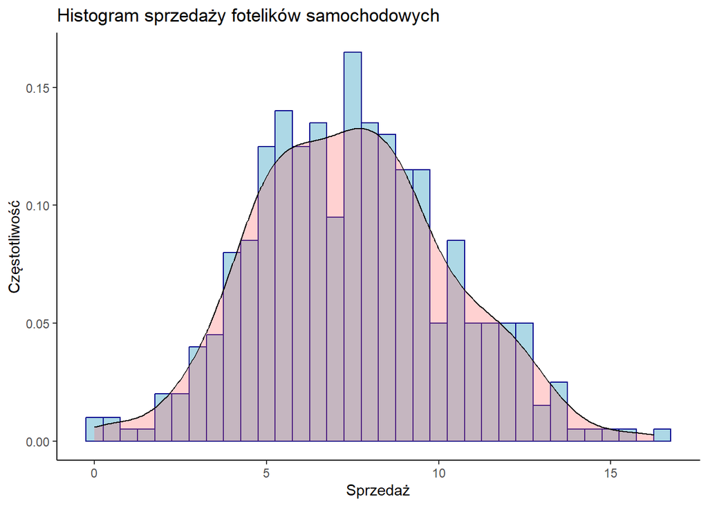

```r
ggplot(carseats, aes(x=Sales))+
  labs(title = 'Histogram sprzedaży fotelików samochodowych',
       x = 'Sprzedaż',
       y = 'Częstotliwość') +
  geom_histogram(aes(y=..density..),
                 color="darkblue",
                 fill="lightblue",
                 binwidth = 0.5) +
  geom_density(alpha=.3, fill="#FF6666") +
  theme_classic()
```

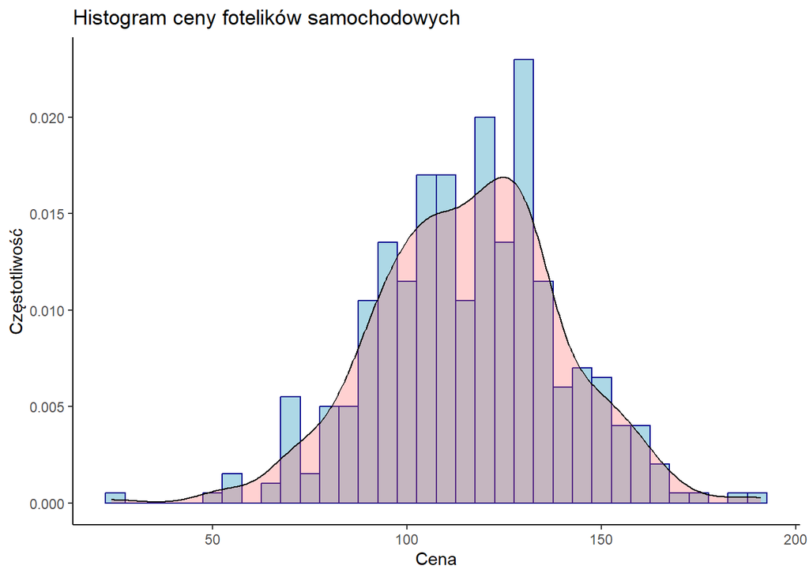

```r
ggplot(carseats, aes(x=Price))+
  labs(title = 'Histogram ceny fotelików samochodowych',
       x = 'Cena',
       y = 'Częstotliwość') +
  geom_histogram(aes(y=..density..),
                 color="darkblue",
                 fill="lightblue",
                 binwidth = 5) +
  geom_density(alpha=.3, fill="#FF6666") +
  theme_classic()
```

Wizualizując rozkłady tych dwóch zmiennych możemy domyśleć się, że posiadają rozkład normalny. Dla potwierdzenia naszej hipotezy użyjemy testu Shapiro-Wilka, który zakłada, że zmienna posiada rozkład normalny.

```r
shapiro.test(carseats$Sales)
```

```
##
##  Shapiro-Wilk normality test
##
## data:  carseats$Sales
## W = 0.9952, p-value = 0.254
```

```r
shapiro.test(carseats$Price)
```

```
##
##  Shapiro-Wilk normality test
##
## data:  carseats$Price
## W = 0.99592, p-value = 0.3902
```

Wnioskując, w obu przypadkach otrzymaliśmy $p$-value $> 0,05$, zatem nie mamy podstaw do odrzucenia $H_0$.

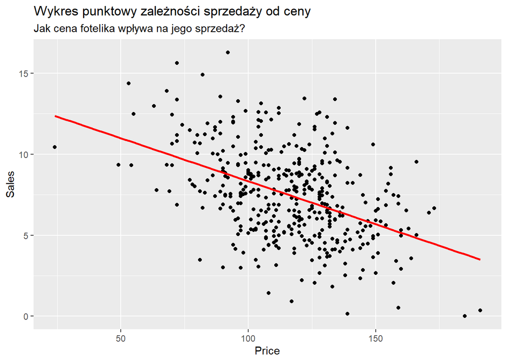

```r
carseats %>%
  ggplot(aes(x = Price,y = Sales)) +
  geom_point() +
  labs(title = 'Wykres punktowy zależności sprzedaży od ceny',
       subtitle = 'Jak cena fotelika wpływa na jego sprzedaż?',
       x = 'Price',
       y = 'Sales') +
  geom_smooth(method='lm' ,formula=y~x, se=F, color = 'red')
```

Wykres nie wyklucza zależności liniowej pomiędzy zmiennymi `Sales` i `Price`, więc przejdziemy do stworzenia modelu regresji liniowej tych zmiennych.